# AllLife Credit Card Customer Segmentation

#### Calculate average silhouette score for both methods. (5 marks)

```python
kmeans_val=[]

for cluster in range(2,20):
    kmeans = KMeans(n_clusters=cluster, random_state=40).fit_predict(ZScore_DF)
    sil_score = metrics.silhouette_score(ZScore_DF,kmeans, metric='euclidean')
    print("The silhouette score for {} cluster k-means: {:.3f}".format(cluster, metrics.silhouette_score(ZScore_DF, kmeans, metric='euclidean')))
kmeans_val.append((cluster,sil_score))
```

```
The silhouette score for 2 cluster k-means: 0.446
The silhouette score for 3 cluster k-means: 0.540
The silhouette score for 4 cluster k-means: 0.367
The silhouette score for 5 cluster k-means: 0.275
The silhouette score for 6 cluster k-means: 0.258
The silhouette score for 7 cluster k-means: 0.236
The silhouette score for 8 cluster k-means: 0.230
The silhouette score for 9 cluster k-means: 0.221
The silhouette score for 10 cluster k-means: 0.209
The silhouette score for 11 cluster k-means: 0.211
The silhouette score for 12 cluster k-means: 0.212
The silhouette score for 13 cluster k-means: 0.214
The silhouette score for 14 cluster k-means: 0.220
The silhouette score for 15 cluster k-means: 0.217
The silhouette score for 16 cluster k-means: 0.219
The silhouette score for 17 cluster k-means: 0.219
The silhouette score for 18 cluster k-means: 0.223
The silhouette score for 19 cluster k-means: 0.228
```

```python
s_hierarchical_val = []

for cluster in range(2,20,2):
    for linkage_method in ['ward', 'average', 'complete']:
        agglomerative = AgglomerativeClustering(linkage=linkage_method, affinity='euclidean',n_clusters=cluster).fit_predict(Hcluster_DF)
        sil_score = metrics.silhouette_score(Hcluster_DF, agglomerative, metric='euclidean')
        s_hierarchical_val.append((cluster, sil_score, linkage_method, len(set(agglomerative)) ) )

C_hierarchical_DF = pd.DataFrame(s_hierarchical_val, columns=['cluster', 'sil_score','linkage_method', 'number_of_clusters'])
C_hierarchical_DF
```

|  | cluster | sil_score | linkage_method | number_of_clusters |
| --- | --- | --- | --- | --- |
| 0 | 2 | 0.432891 | ward | 2 |
| 1 | 2 | 0.580762 | average | 2 |
| 2 | 2 | 0.580762 | complete | 2 |
| 3 | 4 | 0.357197 | ward | 4 |
| 4 | 4 | 0.492410 | average | 4 |
| 5 | 4 | 0.393088 | complete | 4 |
| 6 | 6 | 0.226114 | ward | 6 |
| 7 | 6 | 0.425798 | average | 6 |
| 8 | 6 | 0.338410 | complete | 6 |
| 9 | 8 | 0.221853 | ward | 8 |
| 10 | 8 | 0.358243 | average | 8 |
| 11 | 8 | 0.220349 | complete | 8 |
| 12 | 10 | 0.185478 | ward | 10 |
| 13 | 10 | 0.360374 | average | 10 |
| 14 | 10 | 0.219813 | complete | 10 |
| 15 | 12 | 0.186472 | ward | 12 |
| 16 | 12 | 0.246128 | average | 12 |
| 17 | 12 | 0.177268 | complete | 12 |
| 18 | 14 | 0.181962 | ward | 14 |
| 19 | 14 | 0.192241 | average | 14 |
| 20 | 14 | 0.174996 | complete | 14 |
| 21 | 16 | 0.185018 | ward | 16 |
| 22 | 16 | 0.190767 | average | 16 |
| 23 | 16 | 0.166498 | complete | 16 |
| 24 | 18 | 0.186255 | ward | 18 |
| 25 | 18 | 0.190506 | average | 18 |
| 26 | 18 | 0.156536 | complete | 18 |

#### Compare K-means clusters with Hierarchical clusters. (5 marks)

```python
Hcluster_DF
```

|  | Avg_Credit_Limit | Total_Credit_Cards | Total_visits_bank | Total_visits_online | Total_calls_made | Hierarchical_Cluster |
| --- | --- | --- | --- | --- | --- | --- |
| 0 | 1.739436 | -1.249084 | -0.864813 | -0.548851 | -1.252966 | 0 |
| 1 | 0.410337 | -0.788414 | -1.480522 | 2.535493 | 1.900849 | 1 |
| 2 | 0.410337 | 1.054266 | -0.864813 | 0.136559 | 0.148730 | 0 |
| 3 | -0.121303 | 0.132926 | -0.864813 | -0.548851 | 0.148730 | 0 |
| 5 | -0.387123 | -0.788414 | -1.480522 | -0.548851 | 1.550425 | 1 |
| ... | ... | ... | ... | ... | ... | ... |
| 655 | 1.712854 | 2.436277 | -0.864813 | 2.535493 | -1.252966 | 2 |
| 656 | 1.314124 | 2.436277 | -0.864813 | 3.563608 | -0.552118 | 2 |
| 657 | 2.935626 | 1.514937 | -0.864813 | 2.192789 | -0.902542 | 2 |
| 658 | 3.653340 | 2.436277 | -0.864813 | 4.249018 | -1.252966 | 2 |
| 659 | 3.520430 | 1.975607 | -1.480522 | 3.220903 | -0.552118 | 2 |

655 rows × 6 columns

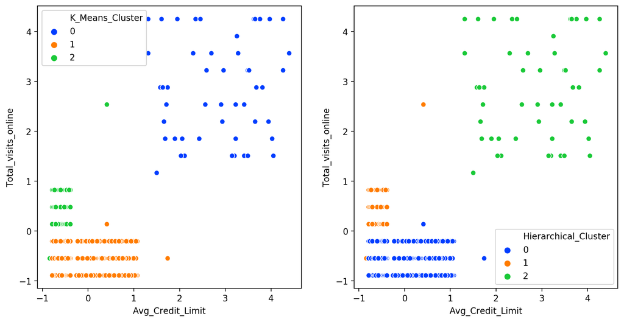

```python
#Using scatter plot for the two principal components to observe the cluster distribution
plt.figure(figsize=(12,6),dpi=200)

plt.subplot(1,2,1)
sns.scatterplot(x='Avg_Credit_Limit' , y='Total_visits_online',data=ZScore_DF,hue='K_Means_Cluster', palette="bright")

plt.subplot(1,2,2)
sns.scatterplot(x='Avg_Credit_Limit', y='Total_visits_online',data=Hcluster_DF,hue='Hierarchical_Cluster', palette="bright")
```

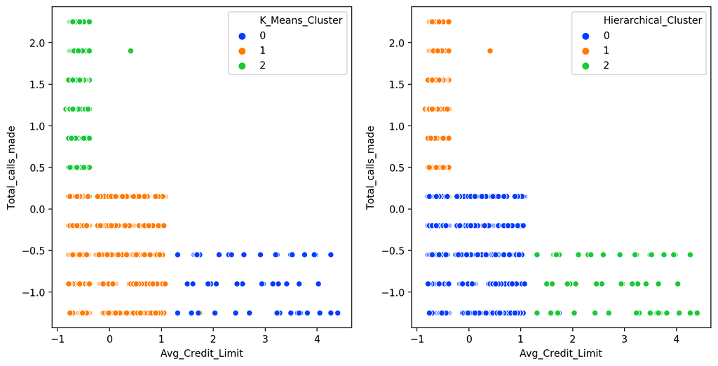

```python
#Using scatter plot for the two principal components to observe the cluster distribution
import matplotlib.pyplot as plt

plt.figure(figsize=(12,6),dpi=200)

plt.subplot(1,2,1)
sns.scatterplot(x='Avg_Credit_Limit' , y='Total_calls_made',data=ZScore_DF,hue='K_Means_Cluster', palette="bright")

plt.subplot(1,2,2)
sns.scatterplot(x='Avg_Credit_Limit', y='Total_calls_made',data=Hcluster_DF,hue='Hierarchical_Cluster', palette="bright")
```

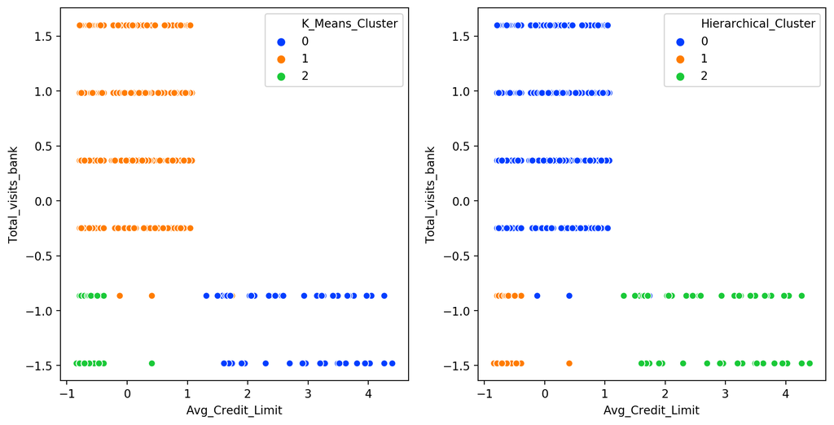

```python
#Using scatter plot for the two principal components to observe the cluster distribution
import matplotlib.pyplot as plt

plt.figure(figsize=(12,6),dpi=200)

plt.subplot(1,2,1)
sns.scatterplot(x='Avg_Credit_Limit' , y='Total_visits_bank',data=ZScore_DF,hue='K_Means_Cluster', palette="bright")

plt.subplot(1,2,2)
sns.scatterplot(x='Avg_Credit_Limit', y='Total_visits_bank',data=Hcluster_DF,hue='Hierarchical_Cluster', palette="bright")
```

#### Analysis the clusters formed, tell us how is one cluster different from another and answer all the key questions. (10 marks)

#### 1. How many different segments of customers are there?

Based on the analysis done using K-Means and H-Clusters, Cluster pattern comparison, the customers can be divided into 3 categories.

- Based on average credit card limit
- Based on number of credit cards
- Based on their interaction with customer services.

#### 2. How are these segments different from each other?

These segments are different from each other based on:

- Average credit limit
- Number of credit cards
- Usage of bank services.

#### 3. What are your recommendations to the bank on how to better market to and service these customers?

The recommendation I would give to bank is to have 3 strategy to target different type of customers:

- For the first category having low average credit limit and fewer number of credit cards, marketing team should approach them with incentive to increase their credit limit and give cashback if they apply for new credit cards.
- Identify active customers such that those that use online services or make more calls in order to apply proper marketing strategy towards them. These people are the main group that we should focus on.
- Introduce loyalty programs like silver, gold and platinum for customers having 5 or more credit cards, the more credit cards customer has better chances they have to upgrade their loyalty program and get more benefits.